# Weight Lifting Exercise Predictive Model

ALee

2022-05-23

# Required Packages

```r
library(caret) # for the confusionmatrix() function (also needs e1071 package)
library(e1071)
library(dplyr)
```

```r
library(ggplot2)
library(xgboost)  # the main algorithm
library(Ckmeans.1d.dp) # for xgb.ggplot.importance
```

# Background

The goal of this project is to predict the manner in which the participants did the exercise. This is the “classe” variable in the training set. We select as many variables to predict the outcome, which is multiclass. The report includes describing how the model is built, how we used cross validation, quantify the expected out of sample error, and why the choices were made. At the end we will use the prediction model to predict 20 different test cases.

As this is a multiclass prediction we use “multi:softprob” as the objective function and “mlogloss” as a metric for model evaluation.

# Load Data

```r
training <- read.csv("pml-training.csv")  #19622x160

testing <- read.csv("pml-testing.csv")    #20x160
```

# Selected Features for Modeling

```r
# two lists of features 54 features and smaller subset of 17 features

cols <- list("classe", "num_window",
         "roll_belt",   "pitch_belt", "yaw_belt",
         "total_accel_belt",
         "gyros_belt_x",    "gyros_belt_y", "gyros_belt_z",
         "accel_belt_x",    "accel_belt_y", "accel_belt_z",
         "magnet_belt_x",   "magnet_belt_y",    "magnet_belt_z",
         "roll_arm",    "pitch_arm",    "yaw_arm",
         "total_accel_arm",
         "gyros_arm_x", "gyros_arm_y",  "gyros_arm_z",
         "accel_arm_x", "accel_arm_y",  "accel_arm_z",
         "magnet_arm_x",    "magnet_arm_y", "magnet_arm_z",
         "roll_dumbbell",   "pitch_dumbbell",   "yaw_dumbbell",
         "total_accel_dumbbell",
         "gyros_dumbbell_x",    "gyros_dumbbell_y", "gyros_dumbbell_z",
         "accel_dumbbell_x",    "accel_dumbbell_y", "accel_dumbbell_z",
         "magnet_dumbbell_x",   "magnet_dumbbell_y",    "magnet_dumbbell_z",
         "roll_forearm",    "pitch_forearm",    "yaw_forearm",
         "total_accel_forearm",
         "gyros_forearm_x", "gyros_forearm_y",  "gyros_forearm_z",
         "accel_forearm_x", "accel_forearm_y",  "accel_forearm_z",
         "magnet_forearm_x",    "magnet_forearm_y", "magnet_forearm_z")

cols_sm <- list("classe",
                "roll_belt", "pitch_belt", "yaw_belt", "total_accel_belt",
                "roll_arm", "pitch_arm",    "yaw_arm",  "total_accel_arm",
                "roll_dumbbell",    "pitch_dumbbell",   "yaw_dumbbell", "total_accel_dumbbell",
                "roll_forearm", "pitch_forearm",    "yaw_forearm", "total_accel_forearm")
```

# XGBoost Algorithm

The XGBoost algorithm requires that the class labels (classe names) start at 0 and increase sequentially to the maximum number of classes. This is a bit of an inconvenience as you need to keep track of what classe name goes with which label. Also, you need to be very careful when you add or remove a 1 to go from the zero based labels to the 1 based labels.

## Full Model

```r
training <- training[, names(training) %in% cols]

cols1 <- cols[-1]        #remove classe from testing

testing <- testing[, names(testing) %in% cols1]
```

## Smaller Model

```r
training <- training[, names(training) %in% cols_sm]  #19622x17

cols_sm1 <- cols_sm[-1]  #remove classe from testing

testing <- testing[, names(testing) %in% cols_sm1]     #20x16
```

## Data Preparation

Here is where we:

- Load the pml-training dataset
- Convert the variable classe from character to factor and to numeric
- Subtract 1 from the classe names so they start at 0
- Print out a summary()

```r
training$classe <- as.numeric(factor(training$classe)) - 1

summary(training)
```

```
##    roll_belt        pitch_belt          yaw_belt       total_accel_belt
##  Min.   :-28.90   Min.   :-55.8000   Min.   :-180.00   Min.   : 0.00
##  1st Qu.:  1.10   1st Qu.:  1.7600   1st Qu.: -88.30   1st Qu.: 3.00
##  Median :113.00   Median :  5.2800   Median : -13.00   Median :17.00
##  Mean   : 64.41   Mean   :  0.3053   Mean   : -11.21   Mean   :11.31
##  3rd Qu.:123.00   3rd Qu.: 14.9000   3rd Qu.:  12.90   3rd Qu.:18.00
##  Max.   :162.00   Max.   : 60.3000   Max.   : 179.00   Max.   :29.00
##     roll_arm         pitch_arm          yaw_arm          total_accel_arm
##  Min.   :-180.00   Min.   :-88.800   Min.   :-180.0000   Min.   : 1.00
##  1st Qu.: -31.77   1st Qu.:-25.900   1st Qu.: -43.1000   1st Qu.:17.00
##  Median :   0.00   Median :  0.000   Median :   0.0000   Median :27.00
##  Mean   :  17.83   Mean   : -4.612   Mean   :  -0.6188   Mean   :25.51
##  3rd Qu.:  77.30   3rd Qu.: 11.200   3rd Qu.:  45.8750   3rd Qu.:33.00
##  Max.   : 180.00   Max.   : 88.500   Max.   : 180.0000   Max.   :66.00
##  roll_dumbbell     pitch_dumbbell     yaw_dumbbell      total_accel_dumbbell
##  Min.   :-153.71   Min.   :-149.59   Min.   :-150.871   Min.   : 0.00
##  1st Qu.: -18.49   1st Qu.: -40.89   1st Qu.: -77.644   1st Qu.: 4.00
##  Median :  48.17   Median : -20.96   Median :  -3.324   Median :10.00
##  Mean   :  23.84   Mean   : -10.78   Mean   :   1.674   Mean   :13.72
##  3rd Qu.:  67.61   3rd Qu.:  17.50   3rd Qu.:  79.643   3rd Qu.:19.00
##  Max.   : 153.55   Max.   : 149.40   Max.   : 154.952   Max.   :58.00
##   roll_forearm       pitch_forearm     yaw_forearm      total_accel_forearm
##  Min.   :-180.0000   Min.   :-72.50   Min.   :-180.00   Min.   :  0.00
##  1st Qu.:  -0.7375   1st Qu.:  0.00   1st Qu.: -68.60   1st Qu.: 29.00
##  Median :  21.7000   Median :  9.24   Median :   0.00   Median : 36.00
##  Mean   :  33.8265   Mean   : 10.71   Mean   :  19.21   Mean   : 34.72
##  3rd Qu.: 140.0000   3rd Qu.: 28.40   3rd Qu.: 110.00   3rd Qu.: 41.00
##  Max.   : 180.0000   Max.   : 89.80   Max.   : 180.00   Max.   :108.00
##      classe
##  Min.   :0.000
##  1st Qu.:0.000
##  Median :2.000
##  Mean   :1.769
##  3rd Qu.:3.000
##  Max.   :4.000
```

## Split Training Dataset into Training and Validate Datasets

```r
set.seed(12345)
# Make split index
train_index <- sample(1:nrow(training), nrow(training)*0.80)  #15697 = 19622 x 0.8

# Full data set - train and validate
data_variables <- as.matrix(training[,-17])
data_label <- training[,"classe"]
data_matrix <- xgb.DMatrix(data = as.matrix(training), label = data_label)

# split train data and make xgb.DMatrix
train_data   <- data_variables[train_index,]                    #15697
train_label  <- data_label[train_index]
train_matrix <- xgb.DMatrix(data = train_data, label = train_label)

# split validate data and make xgb.DMatrix
validate_data  <- data_variables[-train_index,]                 #3925
validate_label <- data_label[-train_index]
validate_matrix <- xgb.DMatrix(data = validate_data, label = validate_label)
```

## Model Specifications

```r
numberOfClasses <- length(unique(training$classe))
xgb_params <- list("objective" = "multi:softprob",
                   "eval_metric" = "mlogloss",
                   "num_class" = numberOfClasses)
nround    <- 50 # number of XGBoost rounds
cv.nfold  <- 5

# Fit cv.nfold * cv.nround XGB models and save OOF predictions
cv_model <- xgb.cv(params = xgb_params,
                   data = train_matrix,
                   nrounds = nround,
                   nfold = cv.nfold,
                   verbose = FALSE,
                   prediction = TRUE)
```

## Out-of-Fold (OOF) Error

```r
OOF_prediction <- data.frame(cv_model$pred) %>%
  mutate(max_prob = max.col(., ties.method = "last"),
         label = train_label + 1)
head(OOF_prediction)
```

```
##             X1           X2           X3           X4           X5 max_prob
## 1 0.0001102053 1.565305e-03 1.856353e-03 9.910055e-01 5.462658e-03        4
## 2 0.0020547288 1.979321e-03 7.312602e-03 9.800874e-04 9.876732e-01        5
## 3 0.0009130082 1.371198e-02 9.842474e-01 4.088624e-04 7.187299e-04        3
## 4 0.9987804294 9.600227e-04 1.855568e-04 3.309159e-05 4.088020e-05        1
## 5 0.0006644825 1.976646e-03 3.403450e-03 9.930800e-01 8.754773e-04        4
## 6 0.9998284578 8.386839e-05 6.607983e-05 3.467814e-06 1.811508e-05        1
##   label
## 1     4
## 2     5
## 3     3
## 4     1
## 5     4
## 6     1
```

```r
# confusion matrix
confusionMatrix(factor(OOF_prediction$max_prob),
                factor(OOF_prediction$label),
                mode = "everything")
```

```
## Confusion Matrix and Statistics
##
##           Reference
## Prediction    1    2    3    4    5
##          1 4420   22    1    1    0
##          2   20 2925   32    3   11
##          3    4   55 2653   17   12
##          4    4    5   26 2570   15
##          5    1    6    1    7 2886
##
## Overall Statistics
##
##                Accuracy : 0.9845
##                  95% CI : (0.9825, 0.9864)
##     No Information Rate : 0.2834
##     P-Value [Acc > NIR] : < 2.2e-16
##
##                   Kappa : 0.9804
##
##  Mcnemar's Test P-Value : 0.002754
##
## Statistics by Class:
##
##                      Class: 1 Class: 2 Class: 3 Class: 4 Class: 5
## Sensitivity            0.9935   0.9708   0.9779   0.9892   0.9870
## Specificity            0.9979   0.9948   0.9932   0.9962   0.9988
## Pos Pred Value         0.9946   0.9779   0.9679   0.9809   0.9948
## Neg Pred Value         0.9974   0.9931   0.9954   0.9979   0.9970
## Precision              0.9946   0.9779   0.9679   0.9809   0.9948
## Recall                 0.9935   0.9708   0.9779   0.9892   0.9870
## F1                     0.9940   0.9744   0.9729   0.9851   0.9909
## Prevalence             0.2834   0.1919   0.1728   0.1655   0.1863
## Detection Rate         0.2816   0.1863   0.1690   0.1637   0.1839
## Detection Prevalence   0.2831   0.1905   0.1746   0.1669   0.1848
## Balanced Accuracy      0.9957   0.9828   0.9856   0.9927   0.9929
```

## Model Performance on the Validate Dataset

```r
bst_model <- xgb.train(params = xgb_params,
                       data = train_matrix,
                       nrounds = nround)

# Predict hold-out validate dataset
validate_pred <- predict(bst_model, newdata = validate_matrix)
validate_prediction <- matrix(validate_pred, nrow = numberOfClasses,
                          ncol=length(validate_pred)/numberOfClasses) %>%
  t() %>%
  data.frame() %>%
  mutate(label = validate_label + 1,
         max_prob = max.col(., "last"))
# confusion matrix of test set
confusionMatrix(factor(validate_prediction$max_prob),
                factor(validate_prediction$label),
                mode = "everything")
```

```
## Confusion Matrix and Statistics
##
##           Reference
## Prediction    1    2    3    4    5
##          1 1126    5    0    0    0
##          2    1  770    7    0    0
##          3    3    9  696    2    0
##          4    1    0    6  615    5
##          5    0    0    0    1  678
##
## Overall Statistics
##
##                Accuracy : 0.9898
##                  95% CI : (0.9861, 0.9927)
##     No Information Rate : 0.2882
##     P-Value [Acc > NIR] : < 2.2e-16
##
##                   Kappa : 0.9871
##
##  Mcnemar's Test P-Value : NA
##
## Statistics by Class:
##
##                      Class: 1 Class: 2 Class: 3 Class: 4 Class: 5
## Sensitivity            0.9956   0.9821   0.9817   0.9951   0.9927
## Specificity            0.9982   0.9975   0.9956   0.9964   0.9997
## Pos Pred Value         0.9956   0.9897   0.9803   0.9809   0.9985
## Neg Pred Value         0.9982   0.9956   0.9960   0.9991   0.9985
## Precision              0.9956   0.9897   0.9803   0.9809   0.9985
## Recall                 0.9956   0.9821   0.9817   0.9951   0.9927
## F1                     0.9956   0.9859   0.9810   0.9880   0.9956
## Prevalence             0.2882   0.1997   0.1806   0.1575   0.1740
## Detection Rate         0.2869   0.1962   0.1773   0.1567   0.1727
## Detection Prevalence   0.2882   0.1982   0.1809   0.1597   0.1730
## Balanced Accuracy      0.9969   0.9898   0.9887   0.9958   0.9962
```

## Prediction on the Test Data

```r
test_matrix <- as.matrix(testing)

# Predict on the new test data
#test_pred <- predict(bst_model, newdata = test_matrix)

# Predict hold-out validate dataset
test_pred <- predict(bst_model, newdata = test_matrix)
test_prediction <- matrix(test_pred, nrow = numberOfClasses,
                          ncol=length(test_pred)/numberOfClasses) %>%
  t() %>%
  data.frame() %>%
  mutate(max_prob = max.col(., "last"))
```

## Feature Importance

The final step in this process, and potentially the first step in a process of understanding the model, is assessing variable importance. Basically, this is a way of using all the splits in the XGBoost trees to understand how accurate the classifications are based on the splits. This is quantified with the Gain measurement in the variable importance table obtained from the xgb.importance() function. According to the XGBoost documentation:

> Gain is the improvement in accuracy brought by a feature to the branches it is on. The idea is that before adding a new split on a feature X to the branch there was some wrongly classified elements, after adding the split on this feature, there are two new branches, and each of these branch is more accurate (one branch saying if your observation is on this branch then it should be classified as 1, and the other branch saying the exact opposite).

```r
# get the feature real names
names <-  colnames(training[,-17])

# compute feature importance matrix
importance_matrix = xgb.importance(feature_names = names, model = bst_model)

head(importance_matrix)
```

```
##          Feature       Gain     Cover  Frequency
## 1:     roll_belt 0.20586784 0.1469803 0.09548924
## 2:      yaw_belt 0.16605548 0.1357428 0.13657183
## 3: pitch_forearm 0.12107003 0.1206570 0.08396947
## 4:    pitch_belt 0.09124330 0.1058830 0.10617627
## 5:  roll_forearm 0.08690281 0.0791609 0.07841777
## 6:  yaw_dumbbell 0.05199203 0.0511169 0.05052047
```

## Feature Importance Plot

The convenient xgb.plot.importance() function takes the Gain information and plots it using ggplot2. The variables are also clustered using k-means clustering that optimizes k based on Bayesian Information Criteria (BIC) for k=1 to k=10, or you can pass a specific k. Here we can see that elements roll_belt, yaw_belt, and pitch_forearm are apparently the most important in classifying each artifact to the accuracy demonstrated by bst_model given the data and hyper-parameters.

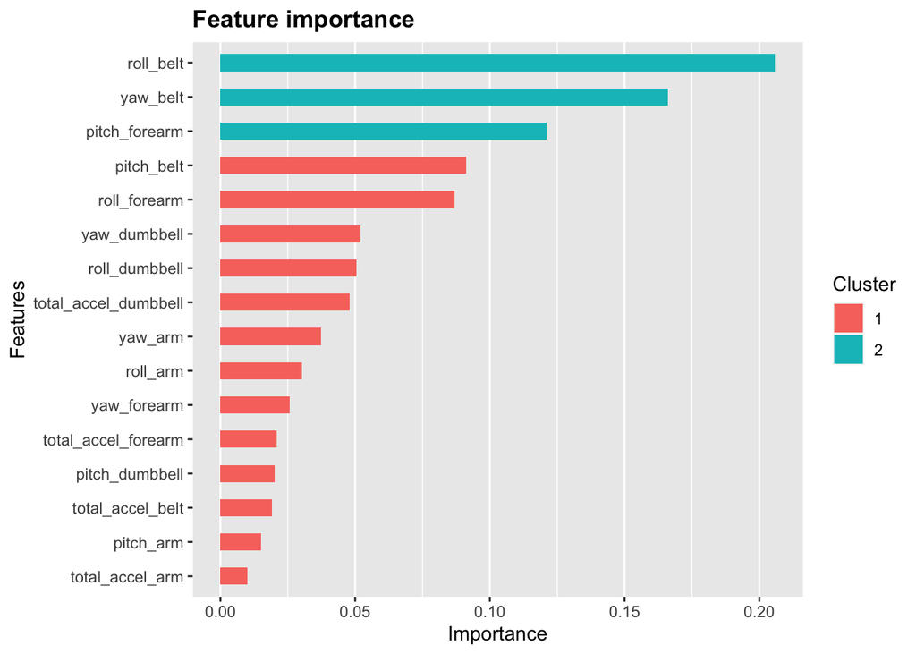

```r
# plot
gp = xgb.ggplot.importance(importance_matrix)

print(gp)
```

# Conclusion

As this is a multiclass prediction, logistic regression (binary) is not applicable. We select XGBoost algorithm as it has outperformed many algorithms, especially winning many machine learning competitions.